# Clustering Employees to Lower Turnover

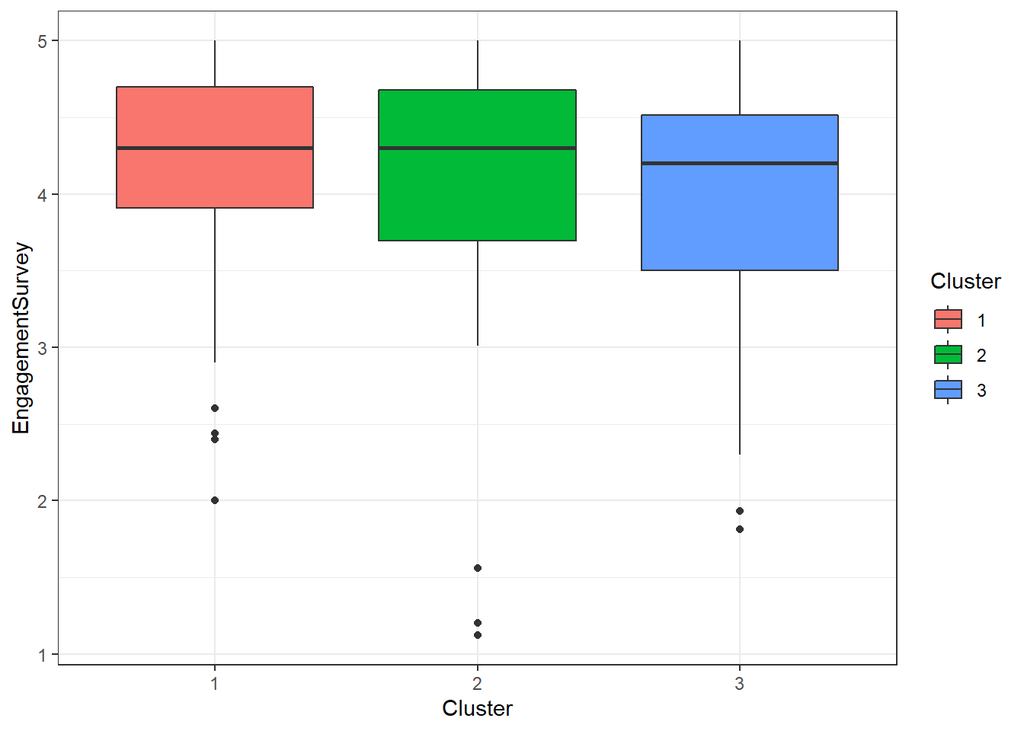

```r
ggplot(data = df_clustered, aes(x = Cluster, y = EngagementSurvey, fill = Cluster)) +
  geom_boxplot()
```

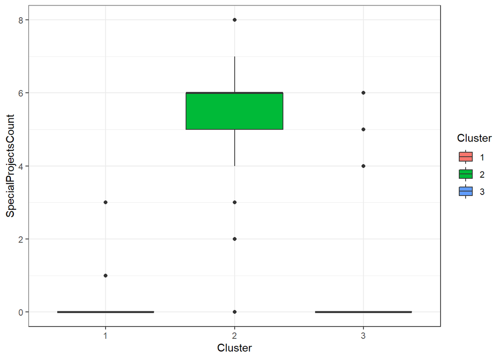

```r
ggplot(data = df_clustered, aes(x = Cluster, y = SpecialProjectsCount, fill = Cluster)) +
  geom_boxplot()
```

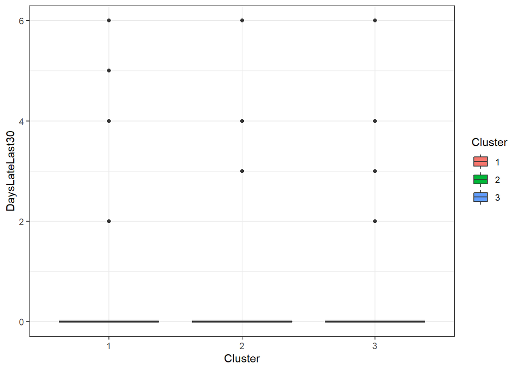

```r
ggplot(data = df_clustered, aes(x = Cluster, y = DaysLateLast30, fill = Cluster)) +
  geom_boxplot()
```

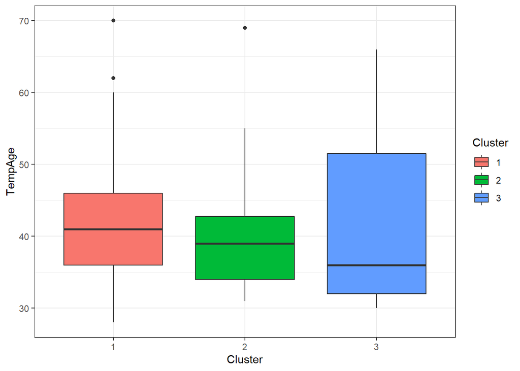

```r
ggplot(data = df_clustered, aes(x = Cluster, y = TempAge, fill = Cluster)) +
  geom_boxplot()
```

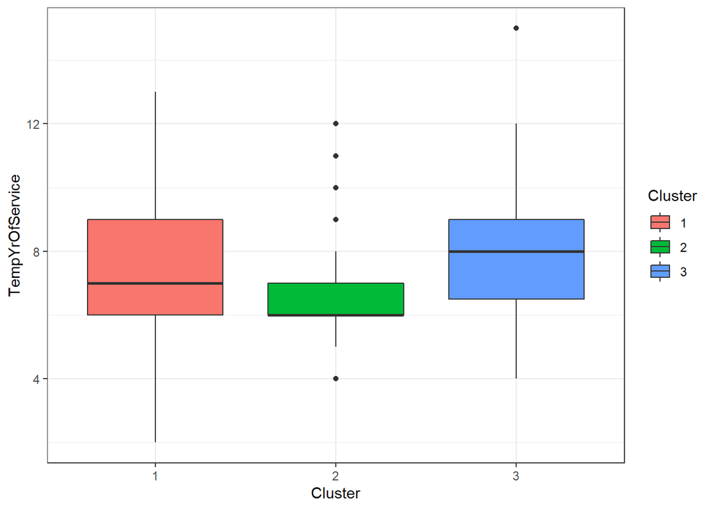

```r
ggplot(data = df_clustered, aes(x = Cluster, y = TempYrOfService, fill = Cluster)) +
  geom_boxplot()
```

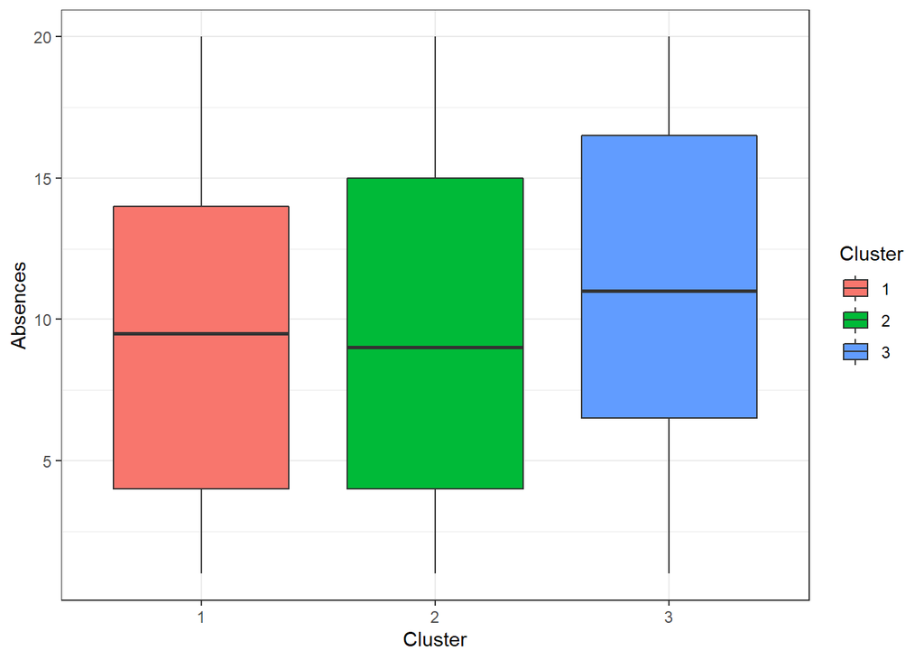

```r
ggplot(data = df_clustered, aes(x = Cluster, y = Absences, fill = Cluster)) +
  geom_boxplot()
```

### Interpreting Clusters

From the data visualization above, the variables below are found to differentiate the clusters from one another.

1. Salary - Cluster 2 has the highest salary, followed by cluster 3 and 1.
2. Position - Cluster 1 tends to have production-related positions, cluster 3 sales-related, and cluster 2 for the others.
3. Department - Cluster 1 tends to come from production department, cluster 3 from sales and executive office, and cluster 2 for the others.
4. Special projects - Cluster 2 has the highest number of special projects, followed by cluster 3 and 1.